# Data Visualization: Day 5

Communication, Polish, And Lightning Round

Erik Westlund

# Welcome Back

## Today’s Goals

1. Add useful annotations directly to figures.
2. Use color, highlighting, and accessibility checks intentionally.
3. Save figures at useful sizes and formats.
4. Preview six resource topics in a lightning round.

## Where We Are

This week moved from setup to visual reasoning:

- workflow
- categorical data
- continuous data
- group comparison
- association

Today has two parts:

- first two hours: annotation, color, and saving images
- last hour: lightning round of visualization examples and wrap-up

# Annotating Figures

## Annotation Directs Attention

Annotation of a figure is one of the most powerful ways to add impact to a visualization.

Useful annotation can mark:

- an important value
- a benchmark
- a visible change
- a group to compare
- a limitation or caution

## Example: Annotation

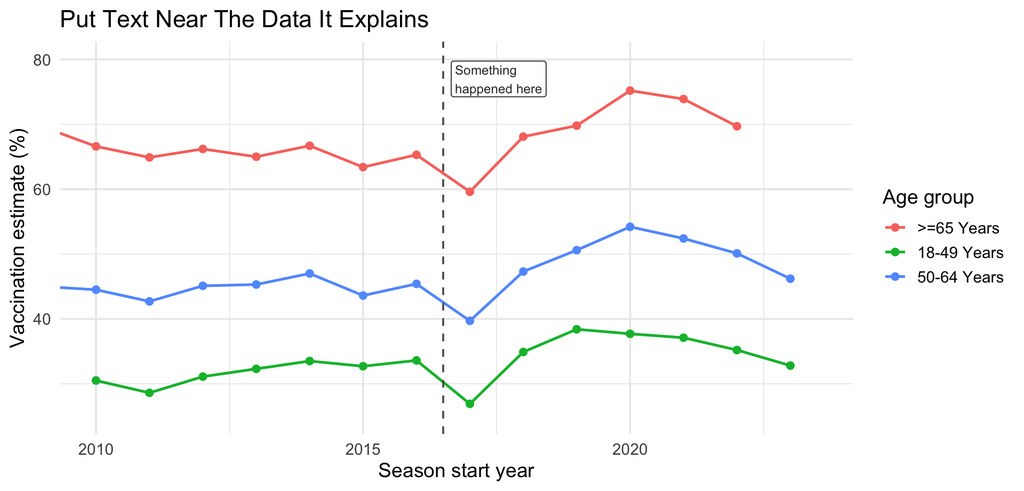

## Transition To Module And Practice

Open:

`modules/07_annotation/01_annotating-data-on-figures.qmd`

Then practice:

`practice/05-communication-and-studio/01_annotating-data-on-figures-practice.qmd`

# Color And Highlighting

## Color Needs Purpose

Color should do something:

- distinguish groups
- show order
- highlight a focus
- encode magnitude
- support accessibility

If color has no job, do not use it.

## Too Many Colors

Many categorical colors can make a plot harder to read.

Consider:

- filtering
- faceting
- direct labels
- highlighting one group
- using gray for context

## Accessibility

- Be conscious of people with vision impairments.
- When using color to differentiate groups or represent a change in magnitude, ensure you use colors that can be distinguished from each other.

## Highlighting

Highlighting a single or small group of standout entities in a figure can be an effective way to draw attention to a key finding.

## Example: Highlighting

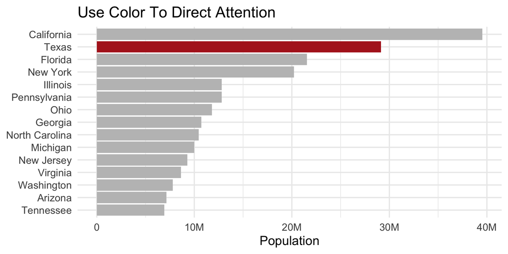

## Transition To Module

Open:

`modules/08_color/01_color-accessibility-and-highlighting.qmd`

Then practice:

`practice/05-communication-and-studio/02_color-accessibility-and-highlighting-practice.qmd`

# Saving Figures

## Exporting Your Visualizations

A figure that works in the RStudio plot pane may fail in:

- slides
- a report
- a paper
- a website
- an assignment submission

Size and format matter.

## Save The Plot Object

Good workflow:

```r
final_plot <- ggplot(...) +
  ...

ggsave("practice/work/figure.png", final_plot, width = 7, height = 5, dpi = 300)
```

- Build the object and then save it with ggsave.
- Pay attention to width, height, and DPI.

## Common Formats

- PNG: slides, websites, most course submissions
- PDF: vector output, print, manuscripts
- SVG: scalable web graphics
- JPEG: almost never appropriate for data visualization

## Transition To Module

Open:

`modules/09_saving/01_saving-visualizations.qmd`

Then practice:

`practice/05-communication-and-studio/03_saving-visualizations-practice.qmd`

# Lightning Round

## Lightning 1: Time Series

Question: how does a value change over ordered time?

Resource: `modules/11_grab-bag/01_time-trends-and-small-multiples.qmd`

## Lightning 2: Before/After

Question: did something change around a reference point?

Resource: `modules/11_grab-bag/02_before-after-and-trajectories.qmd`

## Lightning 3: Process Diagrams

Use R to make it easier to draw diagrams with arrows and boxes.

Resource: `modules/11_grab-bag/03_process-diagrams.qmd`

## Lightning 4: Causal DAGs

Use R to draw directed acylic graphs (DAGs) and assess covariate adjustment sets for causal inference.

Resource: `modules/11_grab-bag/04_causal-dag-graphs.qmd`

## Lightning 5: Maps And Alternatives

Use R to draw maps; consider alternatives to choropleths, which are often misleading.

Resource: `modules/11_grab-bag/05_choropleth-maps-and-alternatives.qmd`

## Lightning 6: Cleveland-Style Diagnostics

Advanced exploratory data analysis following Cleveland.

Resource: `modules/11_grab-bag/06_cleveland_style_diagnostic_plots.qmd`

# Wrap-Up

## Data Visualization Checklist

Before you call a figure finished, check:

- **Question**: does the title or caption make the point clear?
- **Data**: is the unit of observation clear?
- **Variables**: are labels and units readable?
- **Scale**: does the axis support the claim honestly?

## Data Visualization Checklist (cont.)

- **Color**: does color have a job? Is it used effectively?
- **Accessibility**: is the plot readable for all people in all mediums?
- **Annotation**: does text guide attention without clutter?
- **Export**: is the saved file readable at its final size?
- **Destination**: does the file format match where it is going?

## Thank You

Please feel free to reach out with any questions: ewestlund@jhu.edu